# RQ2

Sumit Kundu

## Final Analysis

**2. What are the factors that affect the customers decision making process while choosing their most preferred shop?**

**Analysis**

**1) Data preparation** Out of all 5 shops in the chain, every customer has a shop which they prefer the most. To find out the factors that are responsible for the customers selecting a particular shop as the most preferred shop, we generated 7 new columns. We generated new columns to find out the shop which are closest to every customer (a), the shop from which the buy the mos number of products (b), the shops from which they buy the most number of unique products (c), the shops at which they have the least average price (d), the shops at which they spend most amount of money (e), the most preferred shop (f) and the factor based on which they choose their most preferred shop (g).

To generate the values for column - (f), the most frequent value in the columns - (b), (c), (d) and (e) is selected and assigned to the customers as the most preferred shop. Based on the most preferred shop for each customer, they are assigned different factors. The customers who have the closest shop, shop with least average price or shop with most unique products purchased as the most preferred shop, they are assigned ‘dist’, ‘price’ or ‘satisf’ respectively as the factor. If they have a combination of these three factors, they are assigned ‘dist_price’, ‘dist_satisf’, ‘price_satisf’ or ‘dist_price_satisf’ respectively.

Every product has a sohpistication value attached with it and are meant to satisfy the needs of a customer. Higher the sohpistication value of a product, higher satisfaction they provide to the buyer. The products needed for daily use such as bread, water, etc. are bought in bulk and are considered less sophisticated than the ones that are bought in comparitively lesser quantities such as dvd player, coffee flask, etc. So, here we have assumed that higher the number of unique products bought, higher is the satisfaction of the customer and more cost they will be ready to pay in terms of either distance to travel or in terms of the price of the items.

```r
## Call the packages
library(tidyverse)
library(dplyr)

## Set file path
file_path <- "/home/sumit/Data-Science-with-R/Input Dataset/Cleaned Dataset/Supermarket_DataCleaned.csv"

## Read data from a file
supermarket_data_clean <- read_csv(file_path)

## List of all features present in the data frame
all_features <- colnames(supermarket_data_clean)

## List of selected features
sel_features <- all_features[-c(1,2,8,9,10,16,22,28,34,35,36,37,38,39,40)]

## Create a data frame with only the selected features
supermarket_data_model <- supermarket_data_clean %>% select(sel_features)

## Generate new columns to find the closest shop, shops from which most products are purchased, shops from which most unique products are purchased, shops offfering least average product price and shops at which maximum amount of money is spent by a customers.
supermarket_data_model$min_dist <- str_sub(colnames(supermarket_data_model[,1:5]),-1,-1)[apply(supermarket_data_model[,1:5],1,which.min)]
supermarket_data_model$most_prod_purch_from <- str_sub(names(supermarket_data_model[,6:10]),-1,-1)[max.col(supermarket_data_model[,6:10], "last")]
supermarket_data_model$most_uni_prod_purch_from <- str_sub(names(supermarket_data_model[,11:15]),-1,-1)[max.col(supermarket_data_model[,11:15], "last")]
supermarket_data_model$least_avg_prod_pri <- str_sub(colnames(supermarket_data_model[,16:20]),-1,-1)[apply(supermarket_data_model[,16:20],1,which.min)]
supermarket_data_model$max_amt_purch <- str_sub(names(supermarket_data_model[,21:25]),-1,-1)[max.col(supermarket_data_model[,21:25], "last")]

## Create a data frame having only the newly generated columns
test <- supermarket_data_model[,26:30]

## Gnereate new columns - most preferred shop and categorise the customers based on the factors
for (row in 1:nrow(test)){
  ## Create a vector for each row
  vec <- c(test[row, "most_prod_purch_from"], test[row, "most_uni_prod_purch_from"], test[row, "least_avg_prod_pri"], test[row, "max_amt_purch"])

  ## Sort and find the most preferred shop
  supermarket_data_model[row, "most_pref_shop"] <- names(sort(summary(as.factor(unlist(vec))), decreasing=T)[1:1])

  ## Assign lables to customers (0 or 'dist' - 'distance', 1 or 'price' - 'price', 2 or 'satisf' - 'satisfaction', 3 or 'dist_price' - 'distance and price', 4 or 'dist_satisf' - 'distance and satisfaction', 5 or 'price_satisf' - 'price and satisfaction' and 6 or 'dist_price_satisf' - 'distance, price and satisfaction')
  if (supermarket_data_model[row, "min_dist"] == supermarket_data_model[row, "most_pref_shop"] && supermarket_data_model[row, "least_avg_prod_pri"] == supermarket_data_model[row, "most_pref_shop"] && supermarket_data_model[row, "most_uni_prod_purch_from"] == supermarket_data_model[row, "most_pref_shop"]){
    supermarket_data_model[row, "factor"] <- 6
  }
  else if (supermarket_data_model[row, "min_dist"] == supermarket_data_model[row, "most_pref_shop"] && supermarket_data_model[row, "least_avg_prod_pri"] == supermarket_data_model[row, "most_pref_shop"]){
    supermarket_data_model[row, "factor"] <- 3
  }
  else if (supermarket_data_model[row, "min_dist"] == supermarket_data_model[row, "most_pref_shop"] && supermarket_data_model[row, "most_uni_prod_purch_from"] == supermarket_data_model[row, "most_pref_shop"]){
    supermarket_data_model[row, "factor"] <- 4
  }
  else if (supermarket_data_model[row, "least_avg_prod_pri"] == supermarket_data_model[row, "most_pref_shop"] && supermarket_data_model[row, "most_uni_prod_purch_from"] == supermarket_data_model[row, "most_pref_shop"]){
    supermarket_data_model[row, "factor"] <- 5
  }
  else if (supermarket_data_model[row, "min_dist"] == supermarket_data_model[row, "most_pref_shop"]){
    supermarket_data_model[row, "factor"] <- 0
  }
  else if (supermarket_data_model[row, "least_avg_prod_pri"] == supermarket_data_model[row, "most_pref_shop"]){
    supermarket_data_model[row, "factor"] <- 1
  }
  else if (supermarket_data_model[row, "most_uni_prod_purch_from"] == supermarket_data_model[row, "most_pref_shop"]){
    supermarket_data_model[row, "factor"] <- 2
  }
  else{
    supermarket_data_model[row, "factor"] <- 7
  }
}

## Re-order columns
supermarket_data_clus <- supermarket_data_model[c(1,2,3,4,5,6,7,8,9,10,11,12,13,14,15,16,17,18,19,20,21,22,23,24,25,32)]
```

**Observations:** Once the data was ready, we plotted a graph and observed that out of 42499 customers who are willing to travel, 42001 customers choose their most preferred shop based on their ‘satisfaction’ or ‘shopping experiece’, whereas others decide based on ‘price’ (4), ‘price and satisfaction’ (19) and others (475). Of the 17866 customers who don’t like to travel and choose the shop closest to them as the most preferred shop, 17221 customers opted for them based on ‘distance and satisfaction’, whereas others concluded based on ‘distance’ (620), ‘distance and price’ (0) and ‘distance, price and satisfaction’ (25).

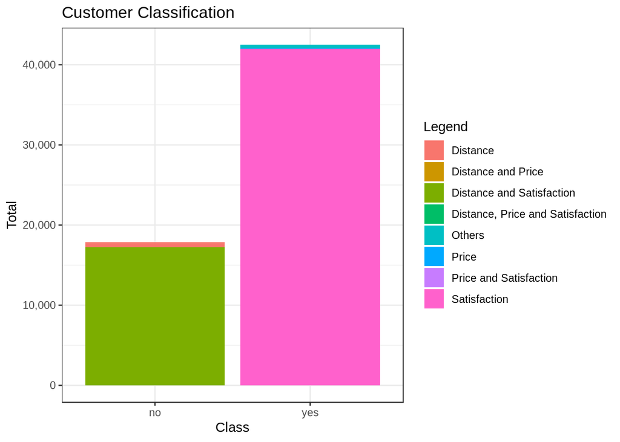

```r
## Create the legend for the plot
Legend <- c(rep("Distance", 1), rep("Price", 1), rep("Distance and Price", 1), rep("Satisfaction", 1), rep("Distance and Satisfaction", 1), rep("Price and Satisfaction", 1), rep("Distance, Price and Satisfaction", 1), rep("Others", 1))

## Generate the count of columns assigned to each factor
dist <- length(which(supermarket_data_model$factor == 0))
price <- length(which(supermarket_data_model$factor == 1))
dist_price <- length(which(supermarket_data_model$factor == 3))
satisf <- length(which(supermarket_data_model$factor == 2))
dist_satisf <- length(which(supermarket_data_model$factor == 4))
price_satisf <- length(which(supermarket_data_model$factor == 5))
dist_price_satisf <- length(which(supermarket_data_model$factor == 6))
others <- length(which(supermarket_data_model$factor == 7))

## Create a vector of values to be shown in the plot
values <- c(dist, price, dist_price, satisf, dist_satisf, price_satisf, dist_price_satisf, others)

## Create a vector of labels to be shown in the plot
labels <- c("no", "yes")

## Create a data frame to store the vectors
factor_count <- data.frame(labels, values)

## Generate a plot
fc_plot <- ggplot(factor_count, aes(labels, values))

## Add featurs to the plot
fc_plot + geom_bar(stat = "identity", aes(fill = Legend)) +
  xlab("Class") + ylab("Total") +
  ggtitle("Customer Classification") +
  theme_bw() + scale_y_continuous(labels = scales::comma)
```

So, from the above observation we can conclude that ‘satisfaction’ plays a key role in the customer’s decision making process while choosing the most preferred shop.

**Applications:** The insights obtained can be used by the business to devise strategies which will help them to increase their revenue while maintaining their current customer base.